# Final project - Data Cleaning

Havi, Rebecca, Ksenia, Amy

5/6/22

```r
library(tidyverse)
library(here)
library(rio)
library(janitor)
library(stringr)
```

We are using data from the Fragile Families & Child Well-Being Study (Princeton) for this project. The study is longitudinal, with data collected from child participants, their parents/guardians, and their teachers at multiple time points (e.g., Baseline, Year 9, Year 15). More information about the study can be found at the following links:

- https://fragilefamilies.princeton.edu/data-and-documentation/public-data-documentation
- https://fragilefamilies.princeton.edu/documentation

Our research questions are:

1. What is the association between internalizing or externalizing behaviors at age 9 and rates of delinquent behaviors at age 15?
2. Which delinquent behaviors are most frequent for internalizing vs. externalizing behaviors?
3. Do race/ethnicity, gender, or other demographic characteristics impact this association?

The complete data file has more than 17,000 variables. We’ll use the meta-data file, which is like a data dictionary (lists all variables and associated information, such as when it was collected and an explanation of what the variable is), to select the variables of interest, and use the `ff_vars` vector to subset the actual data file.

For this project, we’re interested in:

1. Demographic characteristics of participants:
   1. Self-reported race/ethnicity at age 15
   2. Mother’s report of gender at birth
2. Scales:
   1. Self-Description Questionnaire (SDQ) - Information on internalizing and externalizing behaviors at age 9
   2. Delinquent Behavior Scale at age 9 and age 15
   3. Aggravation in parenting - collected for Baseline all years
3. Outcomes from questionnaire:
   1. Whether or not the child was suspended/expelled from school at age 9 and 15 (parent and child), and number of times suspended or expelled at age 15 (parent and child)

```r
#importing meta-data
ff_meta <- import(here("data","FFMetadata_v09.csv")) %>%
    clean_names() %>%
    as_tibble()
```

```r
#select scales
scales <- c("Aggravation in Parents",
            "Self-Description Questionnaire (SDQ)",
            "Delinquent Behavior")

ff_meta_subset <- ff_meta %>%
                #demographic characteristics - race/ethnicity
                filter((topics == "Demographics" &
                        str_detect(varlab,
                                   "self-description of race/ethnicity")) |
                        #gender
                        (subtopics == "sex/gender" &
                        str_detect(varlab, "Focal baby's gender")) |
                        #scales
                        scale %in% scales|
                        #outcomes from questionnaire
                        (source == "questionnaire" &
                        subtopics == "student experiences" &
                        str_detect(varlab,"suspen"))) %>%
                #only include relevant columns
                select(new_name,
                       varlab,
                       topics,
                       subtopics,
                       type,
                       scale,
                       source,
                       respondent,
                       survey,
                       wave,
                       starts_with("label"))
```

Our meta-data subset includes the following information:

1. variable names corresponding to columns in the actual data set
2. variable labels - actual question statement
3. topics
4. subtopic
5. type - types of variable (continuous, categorical, etc.)
6. scale - which scale was used. “” means no scale was used
7. source
8. respondent
9. survey
10. wave - year and wave data was collected
11. starts_with(“label”) - description of possible responses to questions and how they’re coded.

```r
#use variable names to subset the dataset

ff_vars <- ff_meta_subset$new_name

ff <- import(here("data","FF_allwaves_2020v2_SPSS.sav")) %>%
    clean_names()

ff_sub <- ff %>%
    select(idnum, #identifier
           all_of(ff_vars)) %>%  #our selected variables
    as_tibble()
```

```r
#let's save the subsetted df so that we don't have to clean each time

#export(ff_sub, here("data","ff_sub.Rda"))

ff_sub_orig <- import(here("data","ff_sub.Rda"))
#AW: I appended "_orig" here to retain an original version of the df
```

The variables (columns) have the following attributes:

1. label: variable label
2. names: possible responses for a question

```r
#let's join the meta data to the subset so that we know which scale it comes from

ff_sub_long <- ff_sub_orig %>%
    pivot_longer(
        cols = -1,
        names_to = "response"
    ) %>%
    left_join(ff_meta, by = c("response" = "new_name"))
```

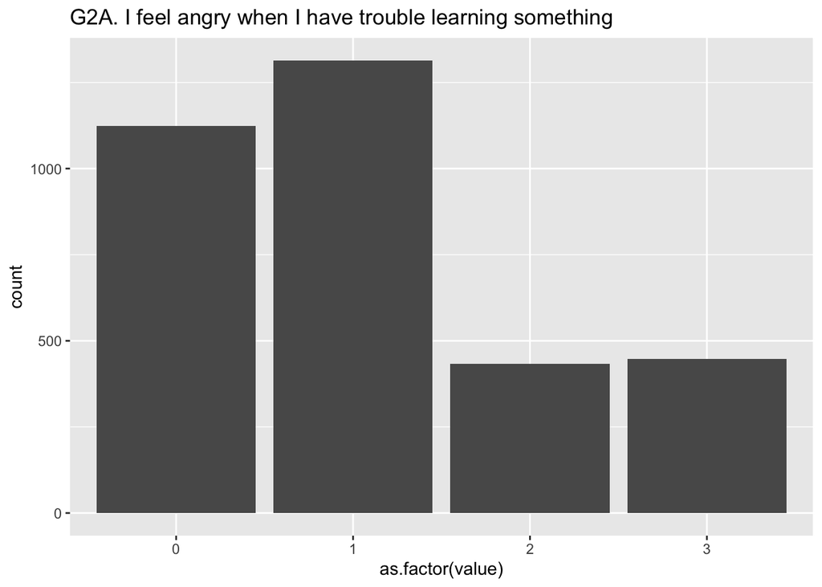

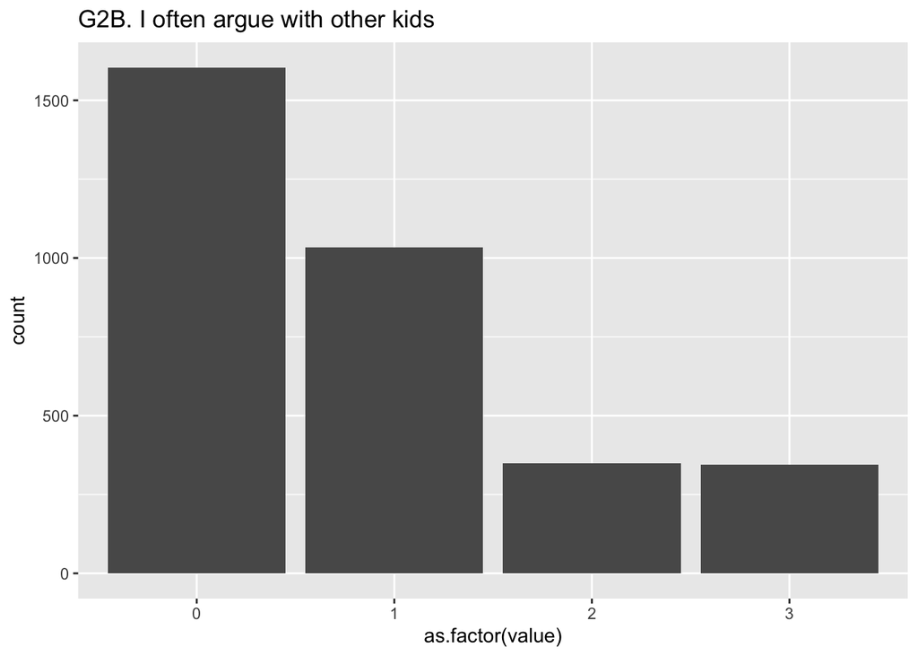

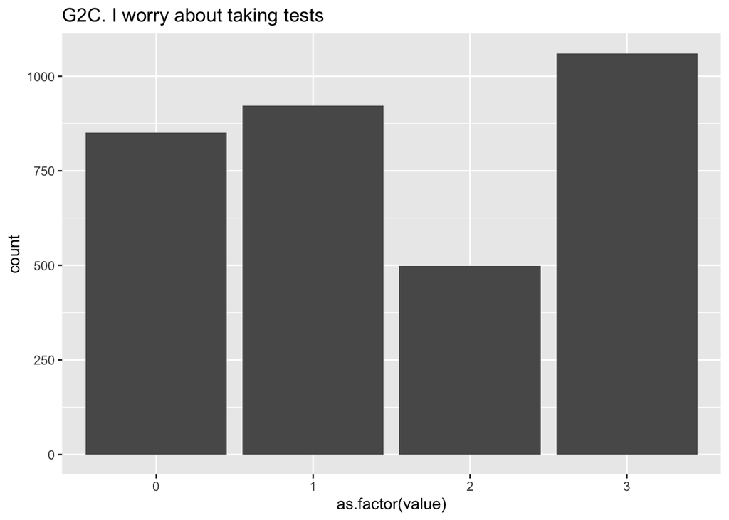

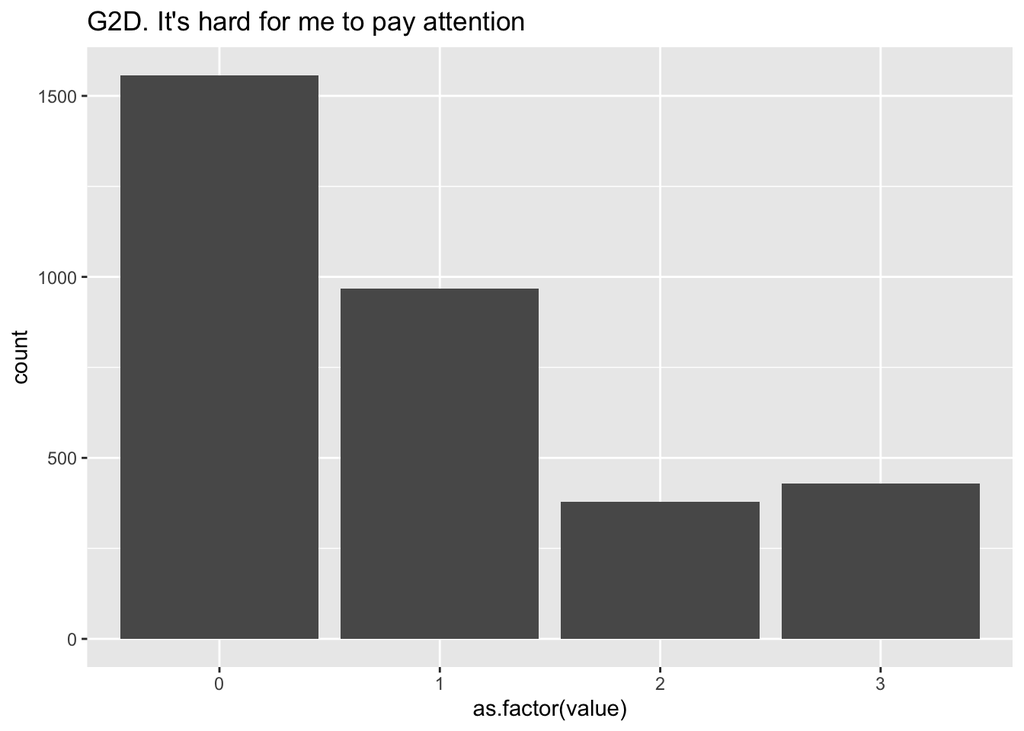

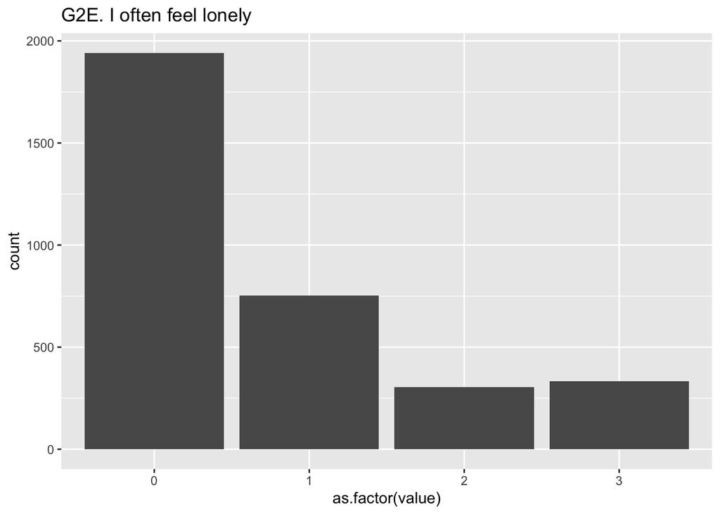

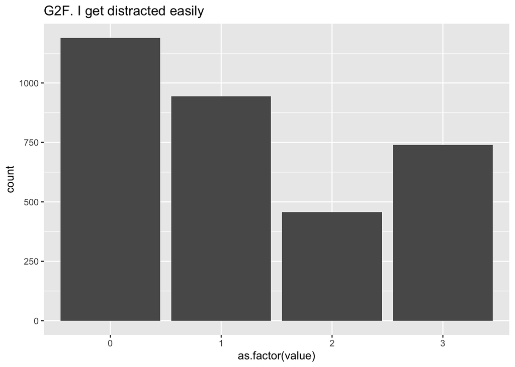

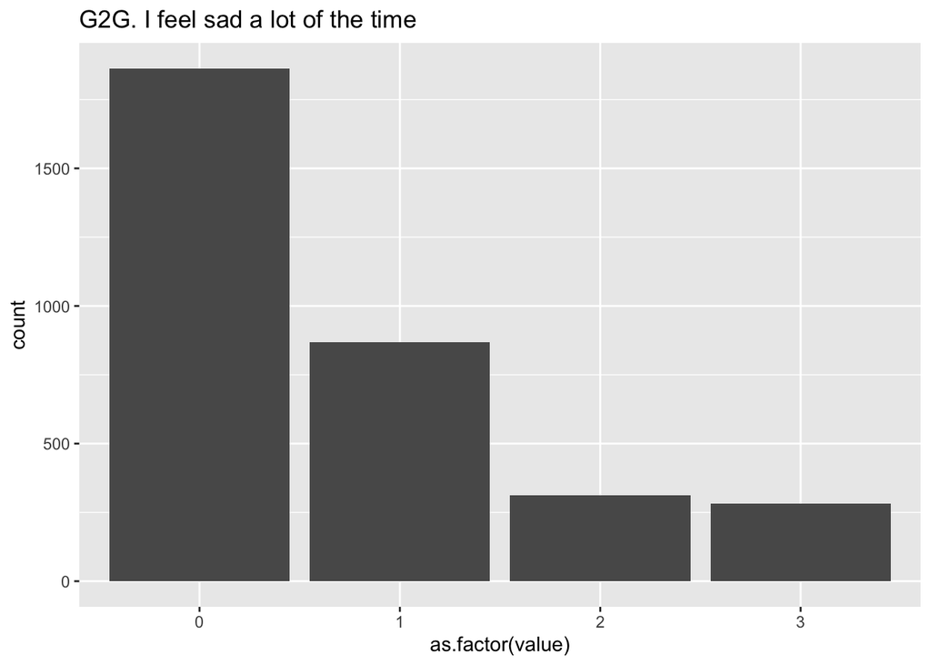

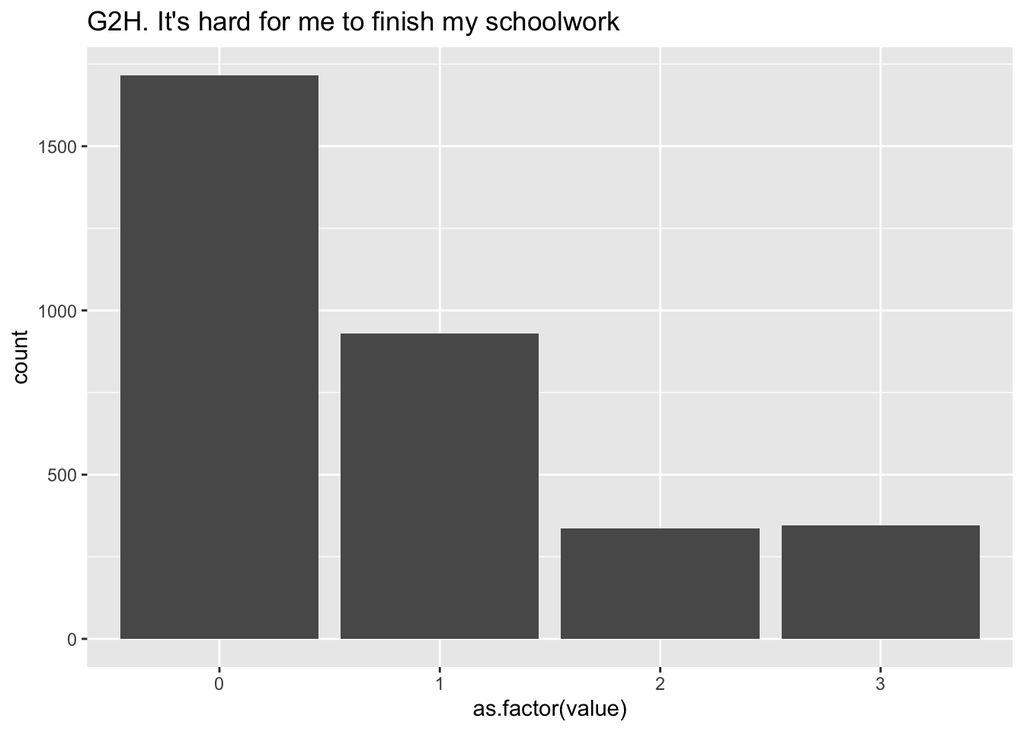

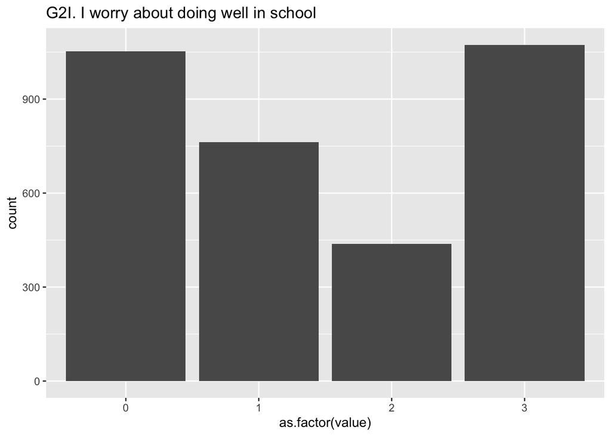

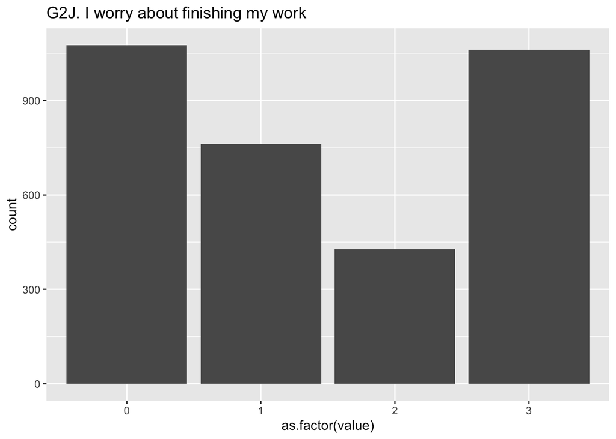

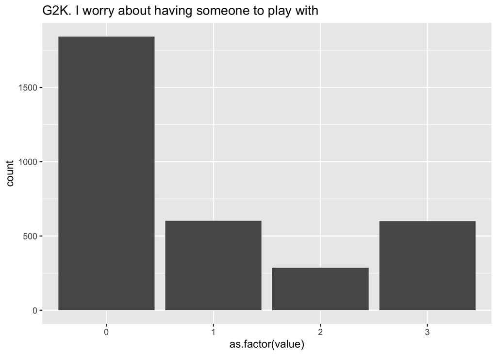

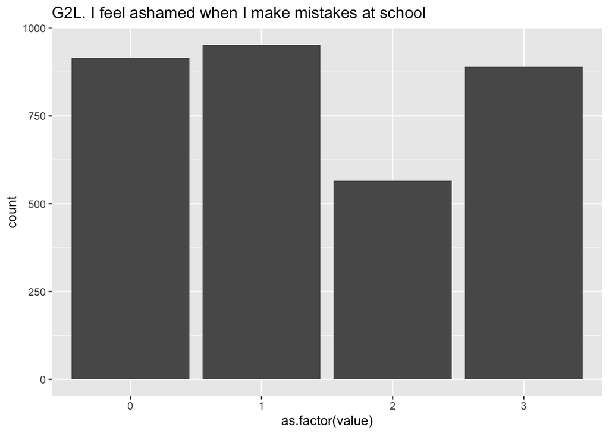

[2 more figures not shown]

```r
#Let's make some example plots

plots <- ff_sub_long %>%
    filter(scale == "Self-Description Questionnaire (SDQ)" & value >= 0) %>%
    nest_by(varlab) %>%
    summarise(
        plot = list(
            ggplot(data, aes(x = as.factor(value))) +
            geom_bar() +
            labs(
                title = glue::glue("{varlab}")
            )
        )
    )

walk(plots$plot, print)
```

## Calculate scores for the internalizing and externalizing subscales

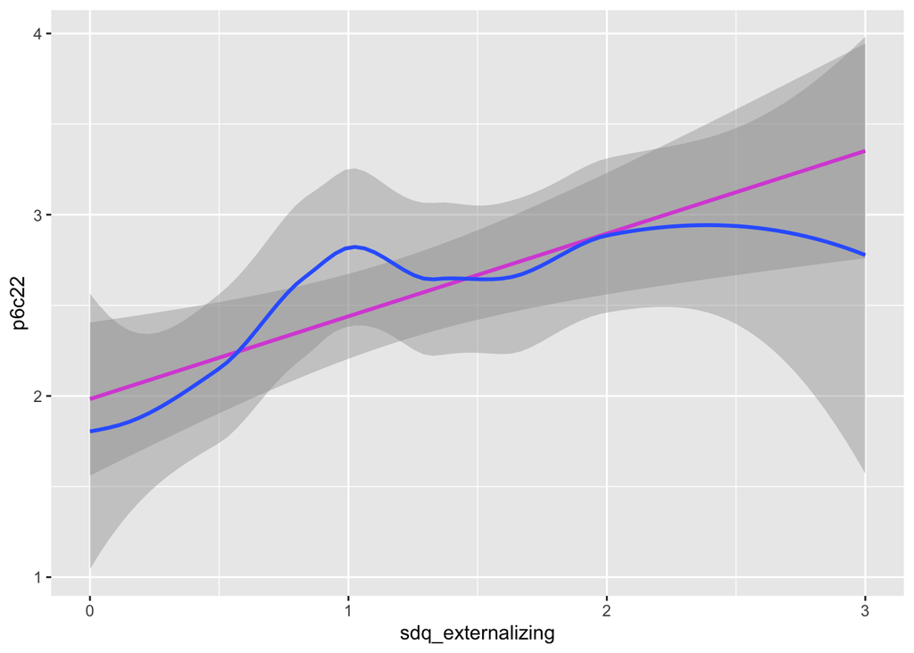

```r
#Calculates subscores for internalizing and externalizing behaviors at age 9
ff_sub <- ff_sub_orig %>%
    mutate(int_scores = (k5g2a + k5g2c + k5g2e + k5g2g +
                             k5g2i + k5g2j + k5g2k + k5g2l) / 8,
           ext_scores = (k5g2b + k5g2d + k5g2f +
                             k5g2h + k5g2m + k5g2n) / 6) %>%
    filter(int_scores >= 0, ext_scores >= 0)

#AW: I think that scores lower than 0 should be filtered out first. Filtering out after calculating the mean will make some participant's scores appear lower than they should be because any negative-coded values are being subtracted from other responses. E.g., let's say a participant had -3, -3, 3, 3, 3, 3. The negative responses are getting subtracted from the sum before dividing. After re-reading the instructions for calculating the subscale scores, I don't think the participant should get a subscale score if they have any negatively coded items. "When a participant responds with don’t know, refuse, or missing, to any item on a given scale, their scale score will be missing..."

#AW: I was thinking something like the code below could work but realized I don't think we want to filter/subset this way, unless we create separate dataframes for participants with externalizing subscale scores and participants with internalizing subscale scores. There will be some kids with int. scores but not ext. scores and vice versa.

ff_sub2 <- ff_sub_orig %>%
    filter(k5g2b >= 0 &
           k5g2d >= 0 &
           k5g2f >= 0 &
           k5g2h >= 0 &
           k5g2m >= 0 &
           k5g2n >= 0
           ) %>%
    rowwise() %>%
    mutate(sdq_externalizing = mean(c(k5g2b,
                                      k5g2d,
                                      k5g2f,
                                      k5g2h,
                                      k5g2m,
                                      k5g2n)
                                    )
           ) %>%
    ungroup()

#AW: I replicated the externalizing x suspensions/expulsions plot using the # of times expelled/suspended as reported by parents (p6c22), filtering to remove negative values first
p <- ff_sub2 %>%
    filter(p6c22 >= 0) %>%
    ggplot(aes(sdq_externalizing, p6c22))

p + geom_smooth(method = "lm",
                    color = "magenta") +
    geom_smooth()
```

```r
ff_sub_lm <- ff_sub %>%
    rowwise() %>%
    select(idnum,
           starts_with("k6d6"),
           starts_with("k5f1"),
           int_scores,
           ext_scores,
           cm1bsex,
           ck6ethrace,
           p5l12g,
           p6c22) %>% #AW: p6c21 is a binary yes/no variable (C21. Youth ever been suspended/expelled?). I think we want p6c22 (# times reported by parent) or k6b30 (# times reported by student) instead. I changed this and subsequent instances to p6c22
    filter(rowSums(across(where(is.numeric))) >= 0 &
               ck6ethrace >= 0 &
               p5l12g >= 0 &
               p6c22 >= 0) %>%
    mutate(del_beh_9 = sum(c_across(starts_with("k5f1"))),
           del_beh_15 = sum(c_across(starts_with("k6d6"))))
```

## Function: calculate mean across variables

```r
means_df <- function(df, ...) {
    means <- map(df, mean, ...)
    nas <- map_lgl(means, is.na)
    means_l <- means[!nas]
    as.data.frame(means_l)
}

means_df(ff_sub)
```

```
##    cm1bsex    k5f1a   k5f1b    k5f1c    k5f1d    k5f1e    k5f1f    k5f1g
## 1 1.483629 1.848904 1.88435 1.908081 1.926705 1.689396 1.945329 1.919796
##      k5f1h    k5f1i    k5f1j    k5f1k    k5f1l    k5f1m    k5f1n    k5f1o
## 1 1.974166 1.975068 1.953139 1.990388 1.985882 1.816161 1.963352 1.981376
##      k5f1p    k5f1q    k5g2a     k5g2b    k5g2c     k5g2d     k5g2e    k5g2f
## 1 1.929709 1.943827 1.048363 0.8269751 1.528687 0.9008711 0.7065185 1.219585
##       k5g2g     k5g2h    k5g2i    k5g2j     k5g2k   k5g2l    k5g2m     k5g2n
## 1 0.6996095 0.7894263 1.455392 1.438871 0.8918594 1.42295 1.082908 0.6800841
##      p5l12g     p6c21     p6c22 ck6ethrace     k6b29     k6b30    k6d61a
## 1 0.6794833 0.9933914 -3.956143   1.101532 0.7026134 -4.028237 0.1685191
##      k6d61b    k6d61c    k6d61d    k6d61e    k6d61f    k6d61g    k6d61h
## 1 0.1952538 0.2258937 0.4466807 0.2427155 0.1628117 0.1559027 0.1432863
##      k6d61i    k6d61j    k6d61k    k6d61l    k6d61m  k6d62a   k6d62b   k6d62c
## 1 0.1459898 0.1595074 0.2349054 0.2847702 0.4629018 1.63833 1.497146 1.407029
##     k6d62d   k6d62e   k6d62f   k6d62g   k6d62h   k6d62i   k6d62j   k6d62k
## 1 1.721538 1.796636 1.880144 1.748573 1.739862 1.831481 1.735957 1.639231
##   int_scores ext_scores
## 1   1.149031  0.9166416
```

## Linear Model functions

```r
ff_sub_lm$idnum <- as.numeric(ff_sub_lm$idnum)

ff_sub_lm$ck6ethrace <- as.numeric(ff_sub_lm$ck6ethrace)

lm_mods <- function (vardep, varindep1, varindep2, varindep3, DATA) {
  summary(lm(paste(vardep, "~",
                   varindep1, "+",
                   varindep2, "+",
                   varindep3),
             data = DATA))
  }

lm_mods("del_beh_15", "ext_scores", "cm1bsex", "ck6ethrace", ff_sub_lm)
```

```
##
## Call:
## lm(formula = paste(vardep, "~", varindep1, "+", varindep2, "+",
##     varindep3), data = DATA)
##
## Residuals:
##     Min      1Q  Median      3Q     Max
## -52.470  -0.928   1.403   2.656  16.614
##
## Coefficients:
##             Estimate Std. Error t value Pr(>|t|)
## (Intercept)  44.8834     1.0911  41.136   <2e-16 ***
## ext_scores    0.2531     0.3175   0.797    0.426
## cm1bsex       0.3527     0.5022   0.702    0.483
## ck6ethrace   -0.5726     0.2916  -1.964    0.050 *
## ---
## Signif. codes:  0 '***' 0.001 '**' 0.01 '*' 0.05 '.' 0.1 ' ' 1
##
## Residual standard error: 6.326 on 671 degrees of freedom
## Multiple R-squared:  0.007143,   Adjusted R-squared:  0.002704
## F-statistic: 1.609 on 3 and 671 DF,  p-value: 0.186
```

```r
lm_mods("del_beh_15", "int_scores", "cm1bsex", "ck6ethrace", ff_sub_lm)
```

```
##
## Call:
## lm(formula = paste(vardep, "~", varindep1, "+", varindep2, "+",
##     varindep3), data = DATA)
##
## Residuals:
##     Min      1Q  Median      3Q     Max
## -52.252  -0.939   1.402   2.636  16.410
##
## Coefficients:
##             Estimate Std. Error t value Pr(>|t|)
## (Intercept)  45.5536     1.0589  43.018   <2e-16 ***
## int_scores   -0.2252     0.3332  -0.676    0.499
## cm1bsex       0.2896     0.4966   0.583    0.560
## ck6ethrace   -0.5705     0.2918  -1.955    0.051 .
## ---
## Signif. codes:  0 '***' 0.001 '**' 0.01 '*' 0.05 '.' 0.1 ' ' 1
##
## Residual standard error: 6.327 on 671 degrees of freedom
## Multiple R-squared:  0.006878,   Adjusted R-squared:  0.002438
## F-statistic: 1.549 on 3 and 671 DF,  p-value: 0.2006
```

```r
lm_mods("del_beh_9", "int_scores", "cm1bsex", "ck6ethrace", ff_sub_lm)
```

```
##
## Call:
## lm(formula = paste(vardep, "~", varindep1, "+", varindep2, "+",
##     varindep3), data = DATA)
##
## Residuals:
##     Min      1Q  Median      3Q     Max
## -65.193  -0.807   0.655   1.555   3.340
##
## Coefficients:
##             Estimate Std. Error t value Pr(>|t|)
## (Intercept) 31.11093    0.55734  55.821  < 2e-16 ***
## int_scores  -0.60890    0.17539  -3.472 0.000550 ***
## cm1bsex      1.01349    0.26138   3.877 0.000116 ***
## ck6ethrace   0.02879    0.15357   0.187 0.851349
## ---
## Signif. codes:  0 '***' 0.001 '**' 0.01 '*' 0.05 '.' 0.1 ' ' 1
##
## Residual standard error: 3.33 on 671 degrees of freedom
## Multiple R-squared:  0.03924,    Adjusted R-squared:  0.03495
## F-statistic: 9.135 on 3 and 671 DF,  p-value: 6.235e-06
```

```r
lm_mods("del_beh_9", "ext_scores", "cm1bsex", "ck6ethrace", ff_sub_lm)
```

```
##
## Call:
## lm(formula = paste(vardep, "~", varindep1, "+", varindep2, "+",
##     varindep3), data = DATA)
##
## Residuals:
##     Min      1Q  Median      3Q     Max
## -64.839  -0.650   0.453   1.314   3.805
##
## Coefficients:
##             Estimate Std. Error t value Pr(>|t|)
## (Intercept)  32.5042     0.5493  59.178  < 2e-16 ***
## ext_scores   -1.3917     0.1598  -8.708  < 2e-16 ***
## cm1bsex       0.6942     0.2528   2.746  0.00619 **
## ck6ethrace   -0.0201     0.1468  -0.137  0.89113
## ---
## Signif. codes:  0 '***' 0.001 '**' 0.01 '*' 0.05 '.' 0.1 ' ' 1
##
## Residual standard error: 3.185 on 671 degrees of freedom
## Multiple R-squared:  0.1213, Adjusted R-squared:  0.1174
## F-statistic: 30.87 on 3 and 671 DF,  p-value: < 2.2e-16
```

```r
lm_mods("p5l12g", "ext_scores", "cm1bsex", "ck6ethrace", ff_sub_lm)
```

```
##
## Call:
## lm(formula = paste(vardep, "~", varindep1, "+", varindep2, "+",
##     varindep3), data = DATA)
##
## Residuals:
##      Min       1Q   Median       3Q      Max
## -0.95410  0.07816  0.14878  0.20082  0.31582
##
## Coefficients:
##             Estimate Std. Error t value Pr(>|t|)
## (Intercept)  1.78997    0.06461  27.705  < 2e-16 ***
## ext_scores  -0.06245    0.01880  -3.322 0.000943 ***
## cm1bsex      0.06021    0.02974   2.025 0.043263 *
## ck6ethrace   0.01093    0.01727   0.633 0.527141
## ---
## Signif. codes:  0 '***' 0.001 '**' 0.01 '*' 0.05 '.' 0.1 ' ' 1
##
## Residual standard error: 0.3746 on 671 degrees of freedom
## Multiple R-squared:  0.02639,    Adjusted R-squared:  0.02204
## F-statistic: 6.062 on 3 and 671 DF,  p-value: 0.0004487
```

```r
lm_mods("p5l12g", "int_scores", "cm1bsex", "ck6ethrace", ff_sub_lm)
```

```
##
## Call:
## lm(formula = paste(vardep, "~", varindep1, "+", varindep2, "+",
##     varindep3), data = DATA)
##
## Residuals:
##     Min      1Q  Median      3Q     Max
## -0.9149  0.1050  0.1603  0.1979  0.2609
##
## Coefficients:
##             Estimate Std. Error t value Pr(>|t|)
## (Intercept)  1.73262    0.06309  27.462   <2e-16 ***
## int_scores  -0.03149    0.01985  -1.586   0.1132
## cm1bsex      0.07448    0.02959   2.517   0.0121 *
## ck6ethrace   0.01326    0.01738   0.763   0.4460
## ---
## Signif. codes:  0 '***' 0.001 '**' 0.01 '*' 0.05 '.' 0.1 ' ' 1
##
## Residual standard error: 0.377 on 671 degrees of freedom
## Multiple R-squared:  0.01408,    Adjusted R-squared:  0.009668
## F-statistic: 3.193 on 3 and 671 DF,  p-value: 0.02313
```

```r
lm_mods("p6c22", "ext_scores", "cm1bsex", "ck6ethrace", ff_sub_lm)
```

```
##
## Call:
## lm(formula = paste(vardep, "~", varindep1, "+", varindep2, "+",
##     varindep3), data = DATA)
##
## Residuals:
##    Min     1Q Median     3Q    Max
## -3.300 -1.604 -1.047  0.412 37.581
##
## Coefficients:
##             Estimate Std. Error t value Pr(>|t|)
## (Intercept)  1.95271    0.59566   3.278   0.0011 **
## ext_scores   0.42653    0.17332   2.461   0.0141 *
## cm1bsex     -0.01671    0.27415  -0.061   0.9514
## ck6ethrace   0.02815    0.15920   0.177   0.8597
## ---
## Signif. codes:  0 '***' 0.001 '**' 0.01 '*' 0.05 '.' 0.1 ' ' 1
##
## Residual standard error: 3.454 on 671 degrees of freedom
## Multiple R-squared:  0.009235,   Adjusted R-squared:  0.004805
## F-statistic: 2.085 on 3 and 671 DF,  p-value: 0.1009
```

```r
lm_mods("p6c22", "ext_scores", "cm1bsex", "ck6ethrace", ff_sub_lm)
```

```
##
## Call:
## lm(formula = paste(vardep, "~", varindep1, "+", varindep2, "+",
##     varindep3), data = DATA)
##
## Residuals:
##    Min     1Q Median     3Q    Max
## -3.300 -1.604 -1.047  0.412 37.581
##
## Coefficients:
##             Estimate Std. Error t value Pr(>|t|)
## (Intercept)  1.95271    0.59566   3.278   0.0011 **
## ext_scores   0.42653    0.17332   2.461   0.0141 *
## cm1bsex     -0.01671    0.27415  -0.061   0.9514
## ck6ethrace   0.02815    0.15920   0.177   0.8597
## ---
## Signif. codes:  0 '***' 0.001 '**' 0.01 '*' 0.05 '.' 0.1 ' ' 1
##
## Residual standard error: 3.454 on 671 degrees of freedom
## Multiple R-squared:  0.009235,   Adjusted R-squared:  0.004805
## F-statistic: 2.085 on 3 and 671 DF,  p-value: 0.1009
```

```r
mod_db_int_15 <- ff_sub_lm %>%
    group_by(idnum) %>%
    nest() %>%
    mutate(
        model = map(
            data, ~lm(del_beh_15 ~ int_scores + cm1bsex + ck6ethrace, data = .x)
        )
    )

mod_db_ext_15 <- ff_sub_lm %>%
    group_by(idnum) %>%
    nest() %>%
    mutate(
        model = map(
            data, ~lm(del_beh_15 ~ ext_scores + cm1bsex + ck6ethrace, data = .x)
        )
    )

mod_db_int_9 <- ff_sub_lm %>%
    group_by(idnum) %>%
    nest() %>%
    mutate(
        model = map(
            data, ~lm(del_beh_9 ~ int_scores + cm1bsex + ck6ethrace, data = .x)
        )
    )

mod_db_ext_9 <- ff_sub_lm %>%
    group_by(idnum) %>%
    nest() %>%
    mutate(
        model = map(
            data, ~lm(del_beh_9 ~ ext_scores + cm1bsex + ck6ethrace, data = .x)
        )
    )

mod_expulsion9_int <- ff_sub_lm %>%
    group_by(idnum) %>%
    nest() %>%
    mutate(
        model = map(
            data, ~lm(p5l12g ~ int_scores + cm1bsex + ck6ethrace, data = .x)
        )
    )

mod_expulsion15_ext <- ff_sub_lm %>%
    group_by(idnum) %>%
    nest() %>%
    mutate(
        model = map(
            data, ~lm(p6c22 ~ ext_scores + cm1bsex + ck6ethrace, data = .x)
        )
    )

mod_expulsion9_ext <- ff_sub_lm %>%
    group_by(idnum) %>%
    nest() %>%
    mutate(
        model = map(
            data, ~lm(p5l12g ~ ext_scores + cm1bsex + ck6ethrace, data = .x)
        )
    )

mod_expulsion15_int <- ff_sub_lm %>%
    group_by(idnum) %>%
    nest() %>%
    mutate(
        model = map(
            data, ~lm(p6c22 ~ int_scores + cm1bsex + ck6ethrace, data = .x)
        )
    )

pull_coef <- function(model, coef_name) {
    coef(model)[coef_name]
}

mod_db_ext_15 %>%
    mutate(intercept = map_dfr(model, pull_coef))
```

```
## # A tibble: 675 × 4
## # Groups:   idnum [675]
##    idnum data              model  intercept$`(Intercept)` $ext_scores $cm1bsex
##    <dbl> <list>            <list>                   <dbl>       <dbl>    <dbl>
##  1     8 <tibble [1 × 49]> <lm>                        47          NA       NA
##  2    14 <tibble [1 × 49]> <lm>                        -8          NA       NA
##  3    19 <tibble [1 × 49]> <lm>                        44          NA       NA
##  4    25 <tibble [1 × 49]> <lm>                        41          NA       NA
##  5    28 <tibble [1 × 49]> <lm>                        46          NA       NA
##  6    30 <tibble [1 × 49]> <lm>                        46          NA       NA
##  7    33 <tibble [1 × 49]> <lm>                        48          NA       NA
##  8    40 <tibble [1 × 49]> <lm>                        47          NA       NA
##  9    48 <tibble [1 × 49]> <lm>                        46          NA       NA
## 10    52 <tibble [1 × 49]> <lm>                        44          NA       NA
## # … with 665 more rows, and 1 more variable: intercept$ck6ethrace <dbl>
```

```r
mod_db_int_15 %>%
    mutate(intercept = map_dfr(model, pull_coef))
```

```
## # A tibble: 675 × 4
## # Groups:   idnum [675]
##    idnum data              model  intercept$`(Intercept)` $int_scores $cm1bsex
##    <dbl> <list>            <list>                   <dbl>       <dbl>    <dbl>
##  1     8 <tibble [1 × 49]> <lm>                        47          NA       NA
##  2    14 <tibble [1 × 49]> <lm>                        -8          NA       NA
##  3    19 <tibble [1 × 49]> <lm>                        44          NA       NA
##  4    25 <tibble [1 × 49]> <lm>                        41          NA       NA
##  5    28 <tibble [1 × 49]> <lm>                        46          NA       NA
##  6    30 <tibble [1 × 49]> <lm>                        46          NA       NA
##  7    33 <tibble [1 × 49]> <lm>                        48          NA       NA
##  8    40 <tibble [1 × 49]> <lm>                        47          NA       NA
##  9    48 <tibble [1 × 49]> <lm>                        46          NA       NA
## 10    52 <tibble [1 × 49]> <lm>                        44          NA       NA
## # … with 665 more rows, and 1 more variable: intercept$ck6ethrace <dbl>
```

```r
mod_db_ext_9 %>%
    mutate(intercept = map_dfr(model, pull_coef))
```

```
## # A tibble: 675 × 4
## # Groups:   idnum [675]
##    idnum data              model  intercept$`(Intercept)` $ext_scores $cm1bsex
##    <dbl> <list>            <list>                   <dbl>       <dbl>    <dbl>
##  1     8 <tibble [1 × 49]> <lm>                        34          NA       NA
##  2    14 <tibble [1 × 49]> <lm>                        33          NA       NA
##  3    19 <tibble [1 × 49]> <lm>                        33          NA       NA
##  4    25 <tibble [1 × 49]> <lm>                        29          NA       NA
##  5    28 <tibble [1 × 49]> <lm>                        33          NA       NA
##  6    30 <tibble [1 × 49]> <lm>                        34          NA       NA
##  7    33 <tibble [1 × 49]> <lm>                        32          NA       NA
##  8    40 <tibble [1 × 49]> <lm>                        33          NA       NA
##  9    48 <tibble [1 × 49]> <lm>                        32          NA       NA
## 10    52 <tibble [1 × 49]> <lm>                        28          NA       NA
## # … with 665 more rows, and 1 more variable: intercept$ck6ethrace <dbl>
```

```r
mod_db_int_9 %>%
    mutate(intercept = map_dfr(model, pull_coef))
```

```
## # A tibble: 675 × 4
## # Groups:   idnum [675]
##    idnum data              model  intercept$`(Intercept)` $int_scores $cm1bsex
##    <dbl> <list>            <list>                   <dbl>       <dbl>    <dbl>
##  1     8 <tibble [1 × 49]> <lm>                        34          NA       NA
##  2    14 <tibble [1 × 49]> <lm>                        33          NA       NA
##  3    19 <tibble [1 × 49]> <lm>                        33          NA       NA
##  4    25 <tibble [1 × 49]> <lm>                        29          NA       NA
##  5    28 <tibble [1 × 49]> <lm>                        33          NA       NA
##  6    30 <tibble [1 × 49]> <lm>                        34          NA       NA
##  7    33 <tibble [1 × 49]> <lm>                        32          NA       NA
##  8    40 <tibble [1 × 49]> <lm>                        33          NA       NA
##  9    48 <tibble [1 × 49]> <lm>                        32          NA       NA
## 10    52 <tibble [1 × 49]> <lm>                        28          NA       NA
## # … with 665 more rows, and 1 more variable: intercept$ck6ethrace <dbl>
```

```r
mod_expulsion15_ext %>%
    mutate(intercept = map_dfr(model, pull_coef))
```

```
## # A tibble: 675 × 4
## # Groups:   idnum [675]
##    idnum data              model  intercept$`(Intercept)` $ext_scores $cm1bsex
##    <dbl> <list>            <list>                   <dbl>       <dbl>    <dbl>
##  1     8 <tibble [1 × 49]> <lm>                         2          NA       NA
##  2    14 <tibble [1 × 49]> <lm>                         0          NA       NA
##  3    19 <tibble [1 × 49]> <lm>                         0          NA       NA
##  4    25 <tibble [1 × 49]> <lm>                         1          NA       NA
##  5    28 <tibble [1 × 49]> <lm>                         1          NA       NA
##  6    30 <tibble [1 × 49]> <lm>                         0          NA       NA
##  7    33 <tibble [1 × 49]> <lm>                         2          NA       NA
##  8    40 <tibble [1 × 49]> <lm>                         2          NA       NA
##  9    48 <tibble [1 × 49]> <lm>                         1          NA       NA
## 10    52 <tibble [1 × 49]> <lm>                        20          NA       NA
## # … with 665 more rows, and 1 more variable: intercept$ck6ethrace <dbl>
```

```r
mod_expulsion15_int%>%
    mutate(intercept = map_dfr(model, pull_coef))
```

```
## # A tibble: 675 × 4
## # Groups:   idnum [675]
##    idnum data              model  intercept$`(Intercept)` $int_scores $cm1bsex
##    <dbl> <list>            <list>                   <dbl>       <dbl>    <dbl>
##  1     8 <tibble [1 × 49]> <lm>                         2          NA       NA
##  2    14 <tibble [1 × 49]> <lm>                         0          NA       NA
##  3    19 <tibble [1 × 49]> <lm>                         0          NA       NA
##  4    25 <tibble [1 × 49]> <lm>                         1          NA       NA
##  5    28 <tibble [1 × 49]> <lm>                         1          NA       NA
##  6    30 <tibble [1 × 49]> <lm>                         0          NA       NA
##  7    33 <tibble [1 × 49]> <lm>                         2          NA       NA
##  8    40 <tibble [1 × 49]> <lm>                         2          NA       NA
##  9    48 <tibble [1 × 49]> <lm>                         1          NA       NA
## 10    52 <tibble [1 × 49]> <lm>                        20          NA       NA
## # … with 665 more rows, and 1 more variable: intercept$ck6ethrace <dbl>
```

```r
mod_expulsion9_ext %>%
    mutate(intercept = map_dfr(model, pull_coef))
```

```
## # A tibble: 675 × 4
## # Groups:   idnum [675]
##    idnum data              model  intercept$`(Intercept)` $ext_scores $cm1bsex
##    <dbl> <list>            <list>                   <dbl>       <dbl>    <dbl>
##  1     8 <tibble [1 × 49]> <lm>                         2          NA       NA
##  2    14 <tibble [1 × 49]> <lm>                         2          NA       NA
##  3    19 <tibble [1 × 49]> <lm>                         2          NA       NA
##  4    25 <tibble [1 × 49]> <lm>                         1          NA       NA
##  5    28 <tibble [1 × 49]> <lm>                         1          NA       NA
##  6    30 <tibble [1 × 49]> <lm>                         2          NA       NA
##  7    33 <tibble [1 × 49]> <lm>                         2          NA       NA
##  8    40 <tibble [1 × 49]> <lm>                         2          NA       NA
##  9    48 <tibble [1 × 49]> <lm>                         2          NA       NA
## 10    52 <tibble [1 × 49]> <lm>                         1          NA       NA
## # … with 665 more rows, and 1 more variable: intercept$ck6ethrace <dbl>
```

```r
mod_expulsion9_int%>%
    mutate(intercept = map_dfr(model, pull_coef))
```

```
## # A tibble: 675 × 4
## # Groups:   idnum [675]
##    idnum data              model  intercept$`(Intercept)` $int_scores $cm1bsex
##    <dbl> <list>            <list>                   <dbl>       <dbl>    <dbl>
##  1     8 <tibble [1 × 49]> <lm>                         2          NA       NA
##  2    14 <tibble [1 × 49]> <lm>                         2          NA       NA
##  3    19 <tibble [1 × 49]> <lm>                         2          NA       NA
##  4    25 <tibble [1 × 49]> <lm>                         1          NA       NA
##  5    28 <tibble [1 × 49]> <lm>                         1          NA       NA
##  6    30 <tibble [1 × 49]> <lm>                         2          NA       NA
##  7    33 <tibble [1 × 49]> <lm>                         2          NA       NA
##  8    40 <tibble [1 × 49]> <lm>                         2          NA       NA
##  9    48 <tibble [1 × 49]> <lm>                         2          NA       NA
## 10    52 <tibble [1 × 49]> <lm>                         1          NA       NA
## # … with 665 more rows, and 1 more variable: intercept$ck6ethrace <dbl>
```

```r
mods <- function(data, x, y, points = FALSE, ...) {
    p <- ggplot(data, aes({{x}}, {{y}}))
    p + geom_smooth(method = "lm",
                    color = "magenta",
                    ...) +
        geom_smooth(...)
}

#AW: Do we want two fitted lines on the graphs? If so, it might be helpful to include a short note about the purpose of the two lines.
```

## Internalizing year 9 x delinquency behaviors in year 15

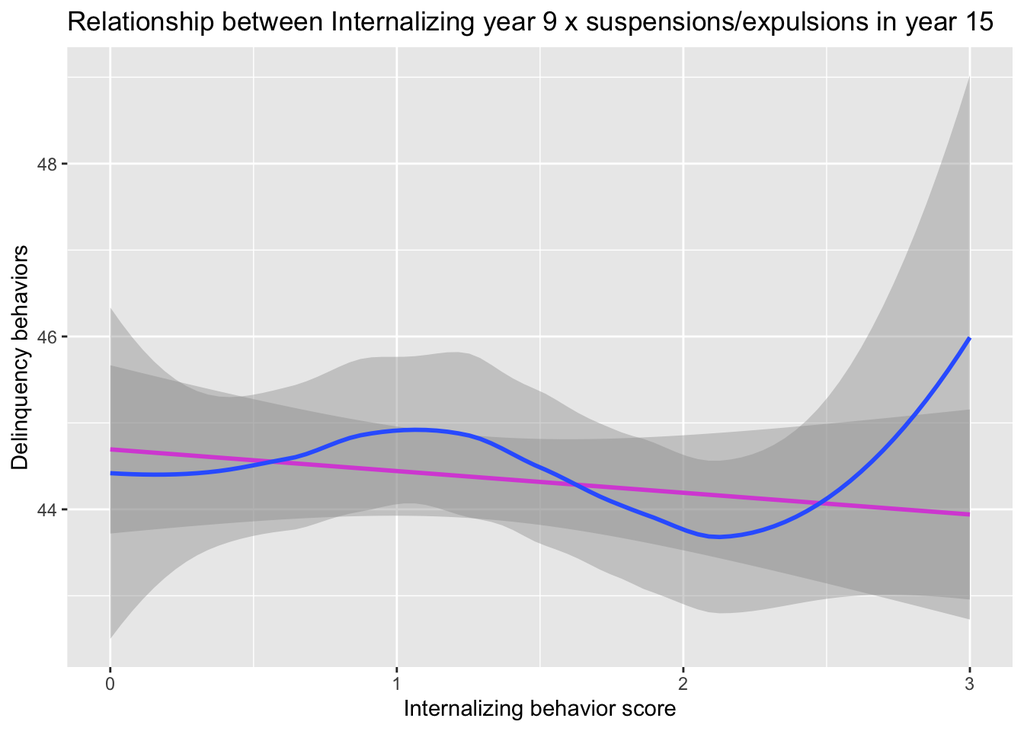

```r
mods(ff_sub_lm, int_scores, del_beh_15) +
    labs(title = "Relationship between Internalizing year 9 x suspensions/expulsions in year 15",
         x = "Internalizing behavior score",
         y = "Delinquency behaviors")
```

## Externalizing behaviors year 9 x delinquency behaviors in year 15

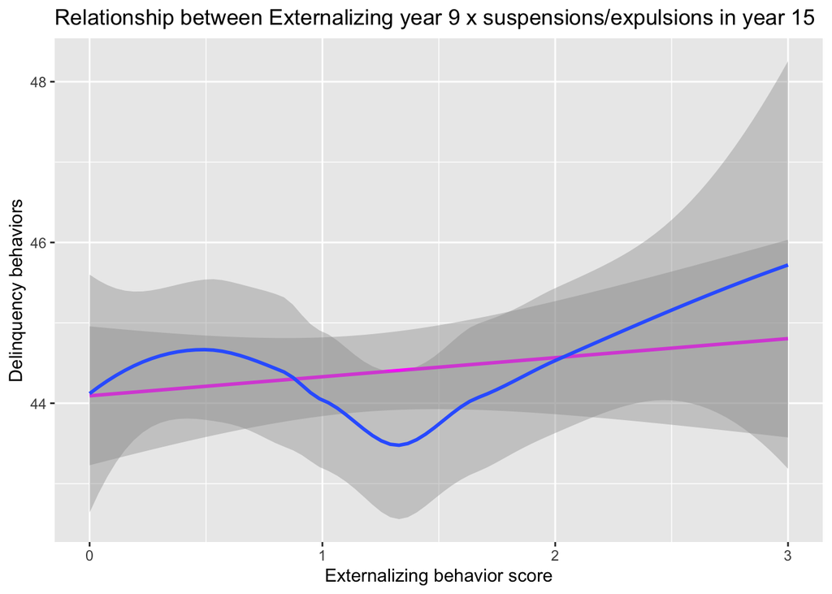

```r
mods(ff_sub_lm, ext_scores, del_beh_15) +
    labs(title = "Relationship between Externalizing year 9 x suspensions/expulsions in year 15",
         x = "Externalizing behavior score",
         y = "Delinquency behaviors")
```

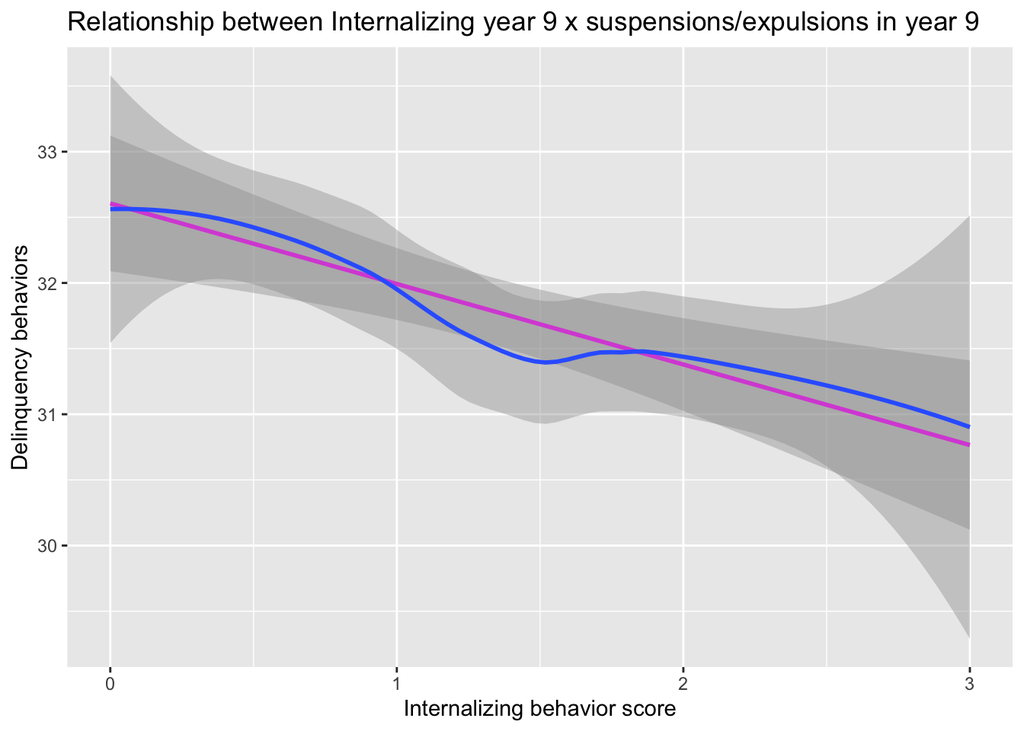

```r
mods(ff_sub_lm, int_scores, del_beh_9) +
    labs(title = "Relationship between Internalizing year 9 x suspensions/expulsions in year 9",
         x = "Internalizing behavior score",
         y = "Delinquency behaviors")
```

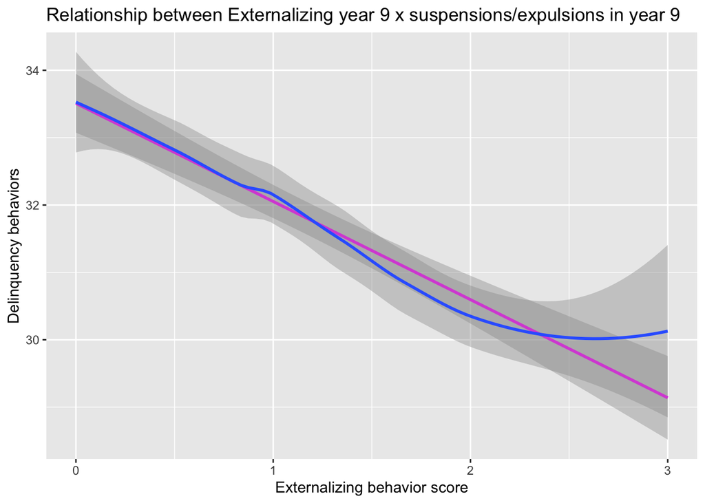

```r
mods(ff_sub_lm, ext_scores, del_beh_9) +
    labs(title = "Relationship between Externalizing year 9 x suspensions/expulsions in year 9",
         x = "Externalizing behavior score",
         y = "Delinquency behaviors")
```

## Internalizing year 9 x suspensions/expulsions in year 9

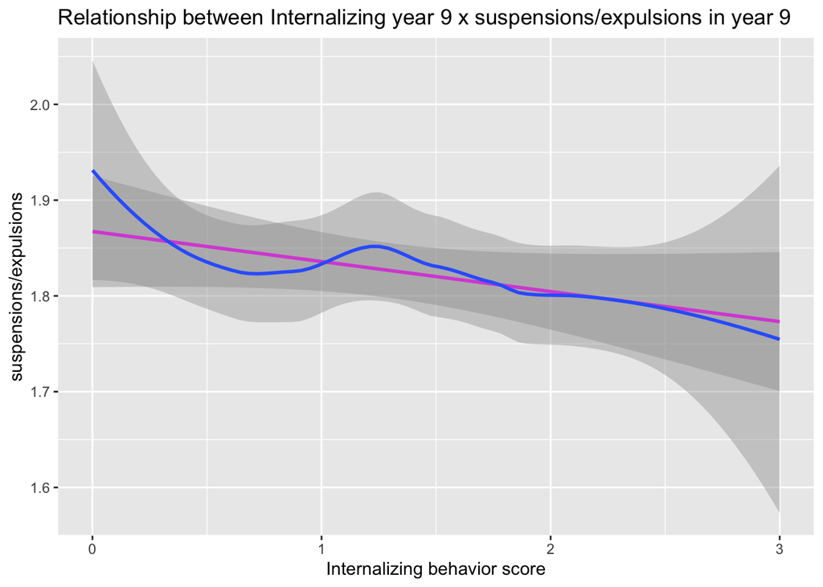

```r
mods(ff_sub_lm, int_scores, p5l12g) +
    labs(title = "Relationship between Internalizing year 9 x suspensions/expulsions in year 9",
         x = "Internalizing behavior score",
         y = "suspensions/expulsions")
```

```r
#AW: p5l12g is a binary yes/no variable. It looks like the # of times the participant was suspended/expelled wasn't collected in Year 9, just a yes/no whether they were or were not.
```

## Externalizing behaviors year 9 x suspensions/expulsions in year 9

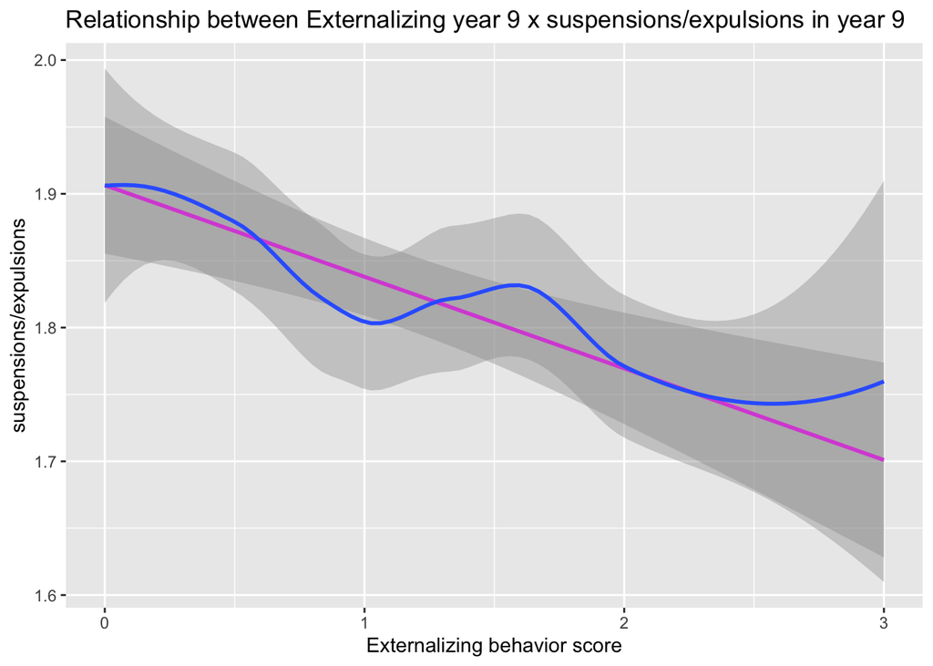

```r
mods(ff_sub_lm, ext_scores, p5l12g) +
    labs(title = "Relationship between Externalizing year 9 x suspensions/expulsions in year 9",
         x = "Externalizing behavior score",
         y = "suspensions/expulsions")
```

```r
#AW: p5l12g is a binary yes/no variable. It looks like the # of times the participant was suspended/expelled wasn't collected in Year 9, just a yes/no whether they were or were not.
```

## Internalizing year 9 x suspensions/expulsions in year 15

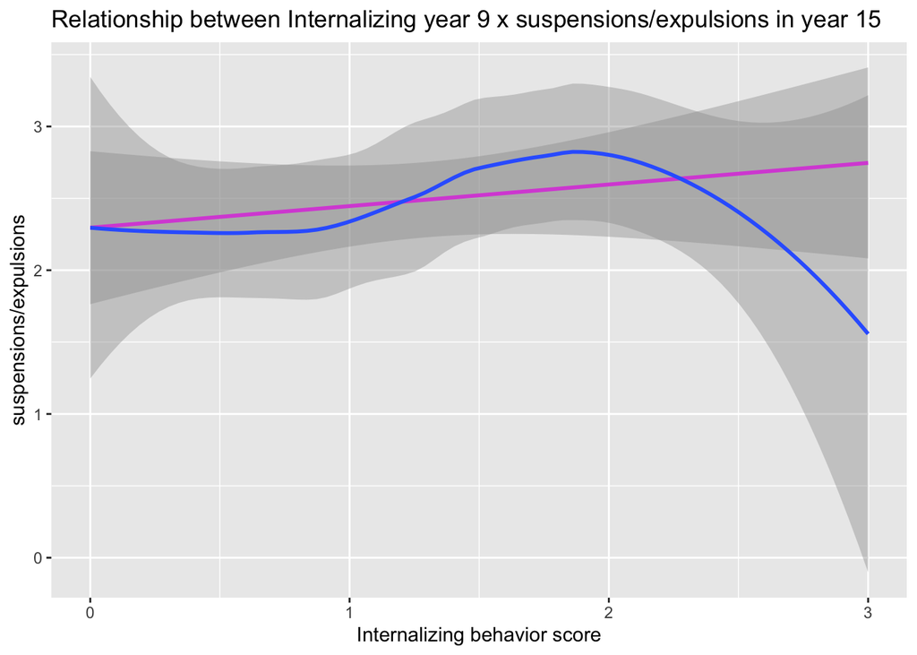

```r
mods(ff_sub_lm, int_scores, p6c22) +
    labs(title = "Relationship between Internalizing year 9 x suspensions/expulsions in year 15",
         x = "Internalizing behavior score",
         y = "suspensions/expulsions")
```

## Externalizing behaviors year 9 x suspensions/expulsions in year 15

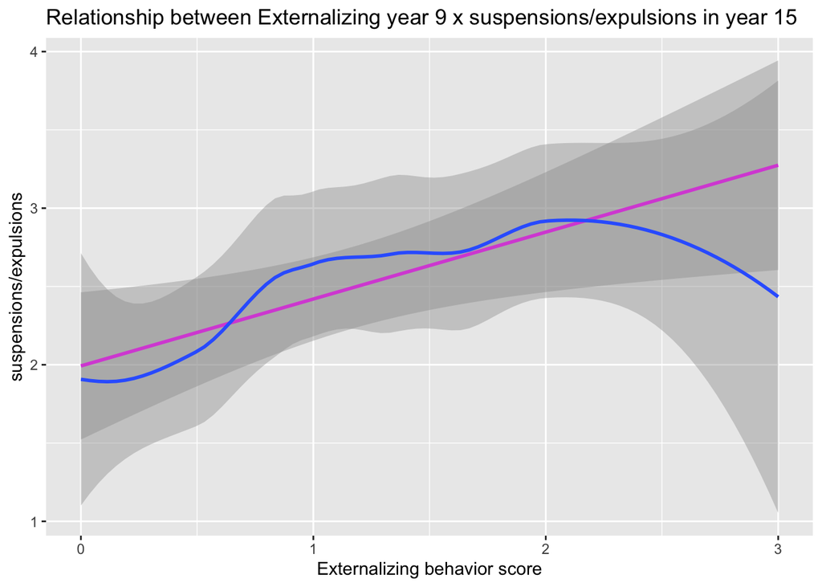

```r
mods(ff_sub_lm, ext_scores, p6c22) +
    labs(title = "Relationship between Externalizing year 9 x suspensions/expulsions in year 15",
         x = "Externalizing behavior score",
         y = "suspensions/expulsions")
```

## purrr::nest %>% mutate()

*This section is still in progress (Amy)*

cm1bsex = gender of participant, as reported by mother during baseline data collection

ck6ethrace = race/ethnicity of participant, self-reported during Wave 6 / Year 15

- 1 = White only, non-hispanic
- 2 = Black/Af. American only, non-hispanic
- 3 = Hispanic/Latino
- 4 = Other only, non-hispanic
- 5 = Multi-racial, non-hispanic
- Negative values = don’t know, missing, refused, and not in wave

p6c22 = Number of times youth has been suspended/expelled past two years as reported by primary caregiver in Wave 6/Year 15

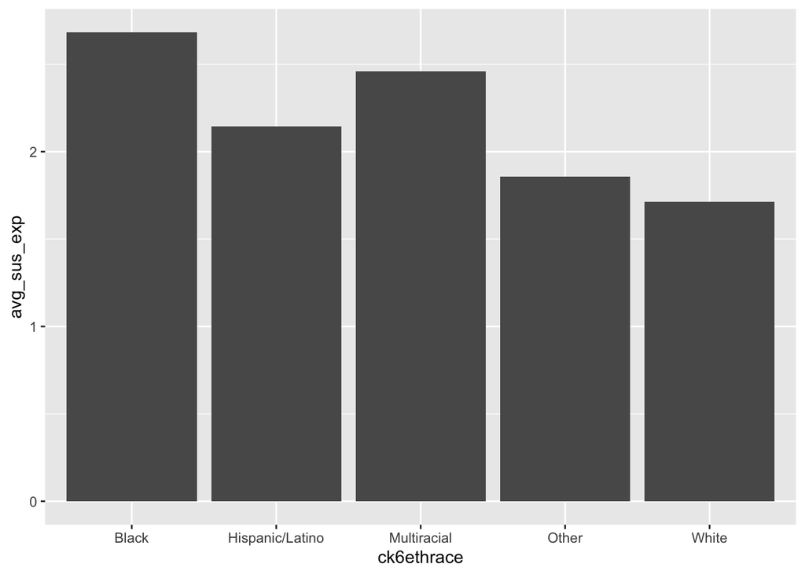

```r
# First step: filter out negatively coded responses for race/ethnicity and # of suspensions/expulsions and recode race/eth
ethrace <- ff_sub %>%
    filter(ck6ethrace > 0,
           p6c22 >= 0) %>%
    mutate(ck6ethrace = recode(ck6ethrace,
                               "1" = "White",
                               "2" = "Black",
                               "3" = "Hispanic/Latino",
                               "4" = "Other",
                               "5" = "Multiracial"))

# Beginning to play around with nest() %>% mutate. Here, I calculated the avg. suspensions/expulsions reported by primary caregiver for Year 15 for each race/eth category.
by_ethrace <- ethrace %>%
        group_by(ck6ethrace) %>%
    nest() %>%
    mutate(
        avg_sus_exp = map_dbl(data, ~mean(.x$p6c22)),
    )

by_ethrace %>%
    ggplot(aes(y = avg_sus_exp, x = ck6ethrace)) +
    geom_col()
```